# 2015-04-25-R-Tip-a-Day-2-Comparison-Packages-for-Data-Manipulation

In the [first post](http://jaehyeon-kim.github.io/r/2015/04/21/R-Tip-a-Day-1-Distinct-Column-Combinations/) of series, a function (`uniqueCol()`) is illustrated. The function returns all combinations of columns that can uniquely identify the records of a data frame and it is created by combining recursive functions. In this post, popular packages or a combination of packages for data manipulation are compared. They are listed below.

- base
- plyr
- dplyr
- data.table
- dplyr + data.table

This post is from a [discussion](https://www.linkedin.com/grp/post/77616-5996370029883510786?trk=groups-post-b-title) in Linkedin’s [The R Project for Statistical Computing](https://www.linkedin.com/grp/home?gid=77616&sort=RECENT) group.

Let’s get started.

The following packages are used.

```r
library(lubridate)
library(ggplot2)
library(data.table)
library(plyr)
library(dplyr)
```

At first, *10000* artificial records of *name*, *territory*, *start date* and *end date* are created. As the first goal is to assign unique ids to individuals, integer ids are mapped to unique names. Then they are merged to the raw data (*preDf*).

```r
set.seed(1237)
trial <- 10000
names <- sample(read.table("http://deron.meranda.us/data/census-derived-all-first.txt")[,1], trial, replace = T)
states <- c("NSW", "VIC", "QLD", "SA", "WA", "ACT", "NT")
territory <- sample(states, trial, replace = T)
start <- ymd(20140101) + days(sample(1:365, trial, replace = T))
inter <- start + months(sample(1:24, trial, replace = T))
end <- inter + months(sample(1:24, trial, replace = T))
preDf <- data.frame(name = names, territory = territory, start = start, end = end)

# create id
uqeName <- data.frame(name = unique(preDf$name), id = 1:length(unique(preDf$name)))
preDf <- merge(preDf, uqeName, by="name", all.x = TRUE)
preDf$id <- as.factor(preDf$id)

head(preDf)
```

```
##    name territory      start        end   id
## 1 AARON       QLD 2014-08-02 2017-06-02 2423
## 2 ABBIE        NT 2014-08-01 2016-08-01 2119
## 3 ABBIE       VIC 2014-04-27 2015-03-27 2119
## 4 ABBIE       NSW 2014-02-13 2017-04-13 2119
## 5  ABBY        WA 2014-05-19 2016-07-19 1038
## 6  ABBY       NSW 2014-12-08 2017-02-08 1038
```

A column is added using each of the packages and this new column is the number of days between the start and end dates (*period*). It is either **unconditional**, which is just obtained by individual rows or **conditional**, which is average periods by id.

### Base

The unconditional period can be obtained by `transform()` while the conditional values need to be obtained by `aggregate()` followed by being merged by `merge()`. Compared to other ways, it requires more lines of code if a new column depends on existing columns. However there may be cases where a 3rd party package is not available or have to be avoided. Then this will be quite beneficial.

```r
## base
# unconditional
postDf <- transform(preDf, period = as.double(end - start))

# conditional
agg <- aggregate(postDf[,5:6], by = list(postDf$id), FUN = function(x) if(is.factor(x)) x else mean(x))[, -2]
names(agg) <- c("id", "period")

postDf <- merge(postDf, agg, by = "id", all.x = T)
```

### plyr

This package is the most flexible as it supports not only data frames but also other data types such as lists, arrarys … However, as shown later, it can be too slow compared to other ways and its use may not be compelling when a new column depend on existing columns.

```r
## plyr
# unconditional
postDf <- plyr::mutate(preDf, period = as.double(end - start))

# conditonal
postDf <- ddply(preDf, .(id), mutate, mean_period = mean(as.double(end - start)))
```

### dplyr

This is a successor of the **plyr** package. Instead of supporting various data types, it only supports data frames (and data tables) to improve speed. It has some SQL-like functions (eg `group_by()`) and thus those who know SQL would find it easier. Interestingly it supports the pipe operator (`%>%`) that chains functions. F# also has a similar operator and people from other programming languages would find it easier than wrapping one or more functions.

```r
## dplyr
# unconditional
postDf <- preDf %>% mutate(period = as.double(end - start))

# conditional
postDf <- preDf %>% group_by(id) %>% mutate(mean_period = mean(as.double(end - start))) %>% arrange(id)
```

### data.table

This package is also popular and it seems to be the fastest. One or more columns can be indexed to further improve speed using `setkey()`. Its syntax seems to be more similar to the functions in the **base** package compared to the previous two packages. I’m not fully sure but a drawback of this package might be it doesn’t seem to provide an easy way that just adding a new column. Actually exising column names should be added in a list but, if the number of columns are many, it can be tedious. There may be a way but I haven’t found and, in this case, the next way can be used for that.

```r
## data.table
# unconditional
preDt <- as.data.table(preDf)
setkey(preDt, id)
postDt <- preDt[, list(name = name, territory = territory,
                       start = start, end = end, id = id,
                       period = as.double(end - start))]

# conditional
postDt <- preDt[,
                list(name = name, territory = territory,
                     start = start, end = end, id = id,
                     mean_period = mean(as.double(end - start))),
                by = id]
```

### dplyr + data.table

The **dplyr** package also supports data tables and there can be cases where using both functions are necessary - an example can be found above.

```r
## dplyr + data.table
# unconditional
postDt <- preDt %>% mutate(period = as.double(end - start))

# conditional
postDt <- preDf %>% group_by(id) %>% mutate(mean_period = mean(as.double(end - start))) %>% arrange(id)

head(postDt)
```

```
## Source: local data frame [6 x 6]
## Groups: id
##
##       name territory      start        end id mean_period
## 1 SHARLENE       ACT 2014-02-14 2016-05-14  1       806.0
## 2 SHARLENE        WA 2014-06-09 2016-08-09  1       806.0
## 3      BEE        NT 2014-05-07 2016-06-07  2       652.4
## 4      BEE        WA 2014-12-10 2015-12-10  2       652.4
## 5      BEE        NT 2014-05-25 2016-02-25  2       652.4
## 6      BEE        NT 2014-07-06 2015-10-06  2       652.4
```

### speed

Time to obtain the conditional column is recorded and their time is plotted. As the **plyr** package takes too long compared to others, it is omitted in the plot.

```r
## speed
tim1 <- system.time({
  postDf <- transform(preDf, period = as.double(end - start))
  agg <- aggregate(postDf[,5:6], by = list(postDf$id), FUN = function(x) if(is.factor(x)) x else mean(x))[, -2]
  names(agg) <- c("id", "period")
  postDf <- merge(postDf, agg, by = "id", all.x = T)
})
tim2 <- system.time(ddply(preDf, .(id), mutate, mean_period = mean(as.double(end - start))))
tim3 <- system.time(preDf %>% group_by(id) %>% mutate(mean_period = mean(as.double(end - start))) %>% arrange(id))
tim4 <- system.time(preDt[,
                          list(name = name, territory = territory,
                               start = start, end = end, id = id,
                               mean_period = mean(as.double(end - start))),
                          by = id])
tim5 <- system.time(preDf %>% group_by(id) %>% mutate(mean_period = mean(as.double(end - start))) %>% arrange(id))

times <- do.call("rbind", list(base = tim1, plyr = tim2, dplyr = tim3, data.table = tim4, both = tim5))
times <- cbind(times, data.frame(package = c("base", "plyr", "dplyr", "data.table", "dplyr+data.table")))
times[, c(1:3,6)]
```

```
##            user.self sys.self elapsed          package
## base           0.555    0.000   0.554             base
## plyr          58.384    0.134  58.542             plyr
## dplyr          0.378    0.000   0.379            dplyr
## data.table     0.328    0.000   0.328       data.table
## both           0.376    0.000   0.376 dplyr+data.table
```

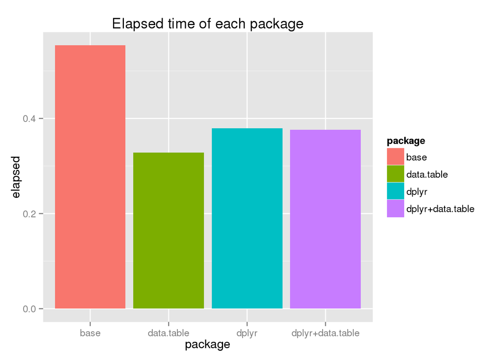

```r
ggplot(times[-2, ], aes(x = package, y = elapsed, fill = package)) +
  geom_bar(stat = "identity") + ggtitle("Elapsed time of each package")
```